# Version 10 results: four panel figures

- Show All Code
- Hide All Code
- View Source

Results of the most recent version (14 September 2026). Every figure and table on this page is drawn by the code shown with it, from the tables versioned in docs/study/data/

Published

September 15, 2026

Home Methods REM GRD v01 v02 corpus v05 v06 v07 v10 results

**Show the code that produced this**

```python
# Everything the figures below need. The drawing code is the code that produced the submitted
# plates: it is generated into this page from docs/study/figuras_*.py by
# scripts/build_version_pages.py, and tests/test_page_figure_code.py fails if the two drift.
import sys
from pathlib import Path

ROOT = Path.cwd().parent if Path.cwd().name == "docs" else Path.cwd()
sys.path.insert(0, str(ROOT / "docs" / "study"))
sys.path.insert(0, str(ROOT / "scripts"))
from report_helpers import kpis, number, show_table
import render_helpers as rh

import sys, json
import numpy as np, pandas as pd
import matplotlib.pyplot as plt
from matplotlib.lines import Line2D
from matplotlib.patches import Patch
from figstyle import *
pd.set_option('mode.chained_assignment', None)
YRS_GRD = list(range(2019, 2025))
YRS_REM = list(range(2021, 2026))
def load_grd_summary():
    g = pd.read_csv(TIDY/'grd_year_summary.csv').query("variant=='sin_rett' and activity=='all'")
    return g
def load_forest():
    m = pd.read_csv(TIDY/'models_summary.csv', low_memory=False).query("variant=='sin_rett'")
    def pick(**kw):
        z = m.copy()
        for k, v in kw.items():
            z = z[z[k].isna()] if v is None else z[z[k] == v]
        assert len(z) == 1, (kw, len(z))
        r = z.iloc[0]; return float(r.apc), float(r.apc_lo), float(r.apc_hi), int(r.df_resid)
    rows = [  # (group, label_en, label_es, values, colour, marker)
     ('grd', 'Any position, observed panel, 2019–24', 'Cualquier posición, panel observado, 2019–24',
      pick(estimand='est_grd_rate', panel='panel_observed', activity='act_all', position='pos_any', covariates='cov_none', years='2019-2024'), BLUE, 'o'),
     ('grd', 'Any position, stable 65 hospitals, 2019–24', 'Cualquier posición, 65 hospitales estables, 2019–24',
      pick(estimand='est_grd_rate', panel='panel_fixed65', activity='act_all', position='pos_any', covariates='cov_none', years='2019-2024'), BLUE, 's'),
     ('grd', 'Any position, adjusted for coding depth, 2019–24', 'Cualquier posición, ajustado por profundidad de codificación, 2019–24',
      pick(estimand='est_grd_rate', panel='panel_observed', activity='act_all', position='pos_any', covariates='cov_depth', years='2019-2024'), BLUE, 'D'),
     ('grd', 'Any position, 2021–24 only', 'Cualquier posición, solo 2021–24',
      pick(estimand='est_grd_rate', panel='panel_observed', activity='act_all', position='pos_any', covariates='cov_none', years='2021-2024'), BLUE, '^'),
     ('grd', 'Strict hospitalisation only, 2019–24', 'Solo hospitalización estricta, 2019–24',
      pick(estimand='est_grd_rate', panel='panel_observed', activity='act_hospitalisation', position='pos_any', covariates='cov_none', years='2019-2024'), BLUE, 'v'),
     ('grd', 'Principal diagnosis, 2019–24', 'Diagnóstico principal, 2019–24',
      pick(estimand='est_grd_rate', panel='panel_observed', activity='act_all', position='pos_principal', covariates='cov_none', years='2019-2024'), ORANGE, 'o'),
     ('pop', 'GRD episodes per resident, both sexes, 2019–24', 'Episodios GRD por residente, ambos sexos, 2019–24',
      pick(estimand='est_grd_pop', sex='TOTAL', covariates='cov_age', years='2019-2024', position='pos_any') if False else None, BLUE, 'o'),
    ]
    # population models: locate by model_id pattern to avoid ambiguity
    def by_id(sub):
        z = m[m.model_id.str.contains(sub, regex=False)]
        assert len(z) == 1, (sub, z.model_id.tolist()); r = z.iloc[0]
        return float(r.apc), float(r.apc_lo), float(r.apc_hi), int(r.df_resid)
    rows = [r for r in rows if r[3] is not None]
    pop_ids = m[m.estimand == 'est_grd_pop'].model_id.tolist()
    def pop(sex):
        z = m[(m.estimand == 'est_grd_pop') & (m.sex == sex) & (m.covariates == 'cov_age') & (m.years == '2019-2024')]
        z = z[z.model_id.str.contains('any')] if len(z) > 1 else z
        assert len(z) == 1, (sex, z.model_id.tolist()); r = z.iloc[0]
        return float(r.apc), float(r.apc_lo), float(r.apc_hi), int(r.df_resid)
    rows += [
     ('pop', 'GRD episodes per resident, males, 2019–24', 'Episodios GRD por residente, hombres, 2019–24', pop('HOMBRE'), BLUE, 'o'),
     ('pop', 'GRD episodes per resident, females, 2019–24', 'Episodios GRD por residente, mujeres, 2019–24', pop('MUJER'), BLUE, 's'),
     ('pop', 'DEIS discharges, principal diagnosis, 2019–24', 'Egresos DEIS, diagnóstico principal, 2019–24', by_id('deis_principal:sin_rett:none:2019-2024'), GREY, 'o'),
     ('rem', 'A05 entries per resident, males, 2021–25', 'Ingresos A05 por residente, hombres, 2021–25', by_id('a05_entry:sin_rett:HOMBRE:age_adjusted:2021-2025'), GREEN, 'o'),
     ('rem', 'A05 entries per resident, females, 2021–25', 'Ingresos A05 por residente, mujeres, 2021–25', by_id('a05_entry:sin_rett:MUJER:age_adjusted:2021-2025'), GREEN, 's'),
     ('rem', 'A05 entries, stable 258 establishments, 2021–25', 'Ingresos A05, 258 establecimientos estables, 2021–25', by_id('a05_entry:sin_rett:stable_pop:none:2021-2025'), GREEN, 'D'),
     ('rem', 'P6 under control, primary care, 2021–25', 'P6 en control, atención primaria, 2021–25', by_id('p6_primary:sin_rett:none:2021-2025'), PINK, 'o'),
     ('rem', 'P6 under control, specialty care, 2021–25', 'P6 en control, especialidad, 2021–25', by_id('p6_specialty:sin_rett:none:2021-2025'), PINK, 's'),
    ]
    return rows
def load_age_rates(source, y0, y1):
    """Combine the verified sex-specific age tables of revision 09 into both-sex rates per 100 000 residents."""
    out = {}
    for y in (y0, y1):
        h = pd.read_csv(DATA/f'{source}_age_hombre_{y}.csv'); m = pd.read_csv(DATA/f'{source}_age_mujer_{y}.csv')
        z = h[['age_group', 'count', 'population']].merge(m[['age_group', 'count', 'population']], on='age_group', suffixes=('_h', '_m'))
        z['count'] = z.count_h + z.count_m; z['pop'] = z.population_h + z.population_m
        z['rate'] = z['count'] / z['pop'] * 1e5
        from scipy import stats
        z['lo'] = stats.chi2.ppf(0.025, 2 * z['count']) / 2 / z['pop'] * 1e5
        z['hi'] = stats.chi2.ppf(0.975, 2 * (z['count'] + 1)) / 2 / z['pop'] * 1e5
        out[y] = z.set_index('age_group')
    return out
F8X_LABELS = {'F80': ('F80 speech/language', 'F80 habla/lenguaje'), 'F81': ('F81 scholastic', 'F81 aprendizaje'),
              'F82': ('F82 motor', 'F82 motriz'), 'F83': ('F83 mixed', 'F83 mixtos'),
              'F84': ('F84 eligible codes', 'F84 códigos elegibles'), 'F88': ('F88 other', 'F88 otros'),
              'F89': ('F89 unspecified', 'F89 inespecífico')}
SHORT = {  # short forest labels (group, en, es)
 'Any position, observed panel, 2019–24': ('Any position, observed panel', 'Cualquier posición, panel observado'),
 'Any position, stable 65 hospitals, 2019–24': ('Stable panel, 65 hospitals', 'Panel estable, 65 hospitales'),
 'Any position, adjusted for coding depth, 2019–24': ('Adjusted for coding depth', 'Ajustado por profundidad'),
 'Any position, 2021–24 only': ('2021–24 only', 'Solo 2021–24'),
 'Strict hospitalisation only, 2019–24': ('Strict hospitalisation only', 'Solo hospitalización estricta'),
 'Principal diagnosis, 2019–24': ('Principal diagnosis', 'Diagnóstico principal'),
 'GRD episodes per resident, males, 2019–24': ('GRD episodes, males', 'Episodios GRD, hombres'),
 'GRD episodes per resident, females, 2019–24': ('GRD episodes, females', 'Episodios GRD, mujeres'),
 'DEIS discharges, principal diagnosis, 2019–24': ('DEIS discharges, principal', 'Egresos DEIS, principal'),
 'A05 entries per resident, males, 2021–25': ('A05 entries, males', 'Ingresos A05, hombres'),
 'A05 entries per resident, females, 2021–25': ('A05 entries, females', 'Ingresos A05, mujeres'),
 'A05 entries, stable 258 establishments, 2021–25': ('A05 entries, stable panel (258)', 'Ingresos A05, panel estable (258)'),
 'P6 under control, primary care, 2021–25': ('P6 under control, primary care', 'P6 en control, atención primaria'),
 'P6 under control, specialty care, 2021–25': ('P6 under control, specialty care', 'P6 en control, especialidad')}
ICD_EN = {'G40': 'Epilepsy (G40)', 'Z51': 'Other medical care (Z51)', 'N47': 'Phimosis, redundant prepuce (N47)', 'K35': 'Acute appendicitis (K35)',
          'J35': 'Tonsil and adenoid disease (J35)', 'J12': 'Viral pneumonia (J12)', 'T43': 'Psychotropic drug poisoning (T43)',
          'F32': 'Depressive episode (F32)', 'J46': 'Status asthmaticus (J46)', 'F60': 'Personality disorders (F60)'}
ICD_ES = {'G40': 'Epilepsia (G40)', 'Z51': 'Otra atención médica (Z51)', 'N47': 'Fimosis, prepucio redundante (N47)', 'K35': 'Apendicitis aguda (K35)',
          'J35': 'Enf. amígdalas y adenoides (J35)', 'J12': 'Neumonía viral (J12)', 'T43': 'Intoxicación psicotrópicos (T43)',
          'F32': 'Episodio depresivo (F32)', 'J46': 'Estado asmático (J46)', 'F60': 'Trastornos de la personalidad (F60)'}
SUB_LABELS = {'F840': ('F84.0 childhood autism', 'F84.0 autismo infantil'), 'F841': ('F84.1 atypical autism', 'F84.1 autismo atípico'),
              'F845': ('F84.5 Asperger', 'F84.5 Asperger'), 'F848': ('F84.8 other', 'F84.8 otros'),
              'F849': ('F84.9 unspecified', 'F84.9 inespecífico'), 'Other': ('F84.3, F84.4', 'F84.3, F84.4')}
A03_ROWS = [  # (code, en, es) in cascade order, M-CHAT-R/F era 2023–2024
 ('09600212', 'Suspected autism in other controls', 'Sospecha en otros controles'),
 ('09600213', 'M-CHAT-R/F first part: low risk', 'M-CHAT-R/F primera parte: riesgo bajo'),
 ('09600214', 'M-CHAT-R/F first part: medium risk', 'M-CHAT-R/F primera parte: riesgo medio'),
 ('09600215', 'M-CHAT-R/F first part: high risk', 'M-CHAT-R/F primera parte: riesgo alto'),
 ('09600216', 'High risk with specialist referral', 'Riesgo alto con derivación a especialista'),
 ('09600218', 'Second part: no referral required', 'Segunda parte: sin derivación'),
 ('09600219', 'Second part: referral required', 'Segunda parte: con derivación')]
def rem_series(code, variant='single_code', measure=None, module=None):
    r = pd.read_csv(TIDY/'rem_pathway_annual.csv', low_memory=False)
    z = r[(r.code.astype(str) == code) & (r.variant == variant)]
    if measure: z = z[z.measure == measure]
    if module: z = z[z.module == module]
    assert len(z) >= 1, (code, variant, measure)
    return z.sort_values('year').set_index('year')
```

```python
import sys
import numpy as np, pandas as pd
import matplotlib.pyplot as plt
from matplotlib.ticker import FuncFormatter
from matplotlib.patches import Ellipse, FancyArrowPatch, FancyBboxPatch, PathPatch
from matplotlib.path import Path as MplPath
from figstyle import *
from figuras_principales import load_grd_summary, load_age_rates, rem_series, YRS_GRD, YRS_REM
CHAP_EN = {'Factores que influyen en el estado de salud': 'Health status and contact with services', 'Sistema respiratorio': 'Respiratory diseases',
           'Sistema nervioso': 'Nervous-system diseases', 'Trastornos mentales y del comportamiento': 'Mental and behavioural, excluding F84',
           'Sistema digestivo': 'Digestive diseases', 'Endocrinas, nutricionales y metabólicas': 'Endocrine, nutritional and metabolic',
           'Síntomas y signos no clasificados': 'Symptoms and signs, unclassified', 'Malformaciones congénitas': 'Congenital malformations',
           'Traumatismos y envenenamientos': 'Injury and poisoning', 'Causas externas': 'External causes', 'Infecciosas y parasitarias': 'Infectious and parasitic',
           'Sistema genitourinario': 'Genitourinary diseases', 'Sangre e inmunidad': 'Blood and immune disorders', 'Sistema circulatorio': 'Circulatory diseases',
           'Piel y tejido subcutáneo': 'Skin and subcutaneous tissue', 'Sistema osteomuscular': 'Musculoskeletal', 'Ojo y anexos': 'Eye and adnexa', 'Oído': 'Ear',
           'Neoplasias': 'Neoplasms', 'Embarazo, parto y puerperio': 'Pregnancy and childbirth', 'Perinatales': 'Perinatal conditions'}
def age_sex_panel(ax, source, y0, y1, lang, ymin):
    for y, filled in ((y0, False), (y1, True)):
        for sex, col, mk in (('hombre', BLUE, 'o'), ('mujer', ORANGE, 's')):
            z = pd.read_csv(DATA/f'{source}_age_{sex}_{y}.csv')
            lab = f"{text('Males', 'Hombres', lang) if sex == 'hombre' else text('Females', 'Mujeres', lang)} {y}"
            ax.errorbar(range(len(z)), z.rate, yerr=[z.rate - z.lo, z.hi - z.rate], fmt=mk + ('-' if filled else '--'), color=col, ms=3, lw=1.0 if filled else 0.9,
                        mfc=col if filled else 'white', capsize=1.2, elinewidth=0.6, label=lab)
        groups = [s.replace('-', '–') for s in z.age_group]
    ax.set_xticks(range(len(groups))); ax.set_xticklabels(groups, rotation=45, ha='right', fontsize=6.6)
    log_axis(ax, 'y', lang); ax.set_ylim(ymin, 1000)
    ax.set_xlabel(text('Age group (years)', 'Grupo de edad (años)', lang)); ax.set_ylabel(text('Records per 100 000 residents\n(log scale)', 'Registros por 100 000 residentes\n(escala log)', lang))
    ax.legend(loc='upper right', fontsize=6.2, ncol=2, handlelength=1.4, columnspacing=0.8, borderaxespad=0.2)
S1_COLOURS = {'grd': ('#0B5FA5', '#E9F1FA'), 'a05': ('#0E7C7B', '#E5F4F3'),
              'p2': ('#177535', '#E9F4ED'), 'b': ('#6C4E94', '#EFEAF7')}
S1_RED, S1_GREY = '#B12D1D', '#474747'
S1_W, S1_H = 2067, 2245
CORPUS = BASE/'corpus'/'tables'
def _s1_in(x, y):
    """A pixel of the inherited 2067x2245 canvas -> inches, for fig.dpi_scale_trans.

    Everything in S1 is drawn in inches rather than in axes fractions so that the rounded corners
    and the cylinder lids stay circular whatever the aspect ratio of the anchor axes."""
    return x/300.0, (S1_H - y)/300.0
def _s1_box(fig, ax, x0, y0, x1, y1, ec, fc='white', lw=1.2, r=0.035):
    """Rounded box in plate pixels. FancyBboxPatch is neither a Rectangle nor a Polygon, so
    overlap_qa._marks() ignores it; set_gid('bg') repeats the exemption explicitly."""
    ix0, iy0 = _s1_in(x0, y1); ix1, iy1 = _s1_in(x1, y0)
    p = FancyBboxPatch((ix0, iy0), ix1 - ix0, iy1 - iy0, boxstyle=f'round,pad=0,rounding_size={r}',
                       transform=fig.dpi_scale_trans, fc=fc, ec=ec, lw=lw, zorder=2, mutation_aspect=1)
    p.set_gid('bg'); ax.add_patch(p); return p
def _s1_cyl(fig, ax, x0, y0, x1, y1, ec, fc='white', lw=1.2, ry=15):
    """Database cylinder in plate pixels; returns the vertical centre of its body (label anchor)."""
    cx, rx = (x0 + x1)/2, (x1 - x0)/2; yt, yb = y0 + ry, y1 - ry
    t = np.linspace(0, np.pi, 60)
    top = np.column_stack([cx + rx*np.cos(t), yt - ry*np.sin(t)])   # right -> left over the lid
    bot = np.column_stack([cx - rx*np.cos(t), yb + ry*np.sin(t)])   # left -> right under the base
    pts = np.vstack([top, [[x0, yb]], bot, [[x1, yt]]])
    verts = [_s1_in(px, py) for px, py in pts]
    body = PathPatch(MplPath(verts, [MplPath.MOVETO] + [MplPath.LINETO]*(len(verts) - 1)),
                     transform=fig.dpi_scale_trans, fc=fc, ec=ec, lw=lw, zorder=2)
    body.set_gid('bg'); ax.add_patch(body)
    lid = Ellipse(_s1_in(cx, yt), (x1 - x0)/300.0, 2*ry/300.0, transform=fig.dpi_scale_trans,
                  fc=fc, ec=ec, lw=lw, zorder=3)
    lid.set_gid('bg'); ax.add_patch(lid)
    return (yt + y1)/2
def _s1_arrow(fig, ax, x0, y0, x1, y1, ec, lw=1.3, ms=12):
    a = FancyArrowPatch(_s1_in(x0, y0), _s1_in(x1, y1), transform=fig.dpi_scale_trans, arrowstyle='-|>',
                        mutation_scale=ms, color=ec, lw=lw, shrinkA=0, shrinkB=0, zorder=4)
    a.set_gid('bg'); ax.add_patch(a)
def _s1_lines(fig, ax, x, y, lines, size=6.8, color=BLACK, weight='normal'):
    """One Text artist per box: the QA overlap check then only has to see that boxes do not collide."""
    ix, iy = _s1_in(x, y)
    return ax.text(ix, iy, '\n'.join(lines), transform=fig.dpi_scale_trans, ha='center', va='center',
                   fontsize=size, color=color, fontweight=weight, linespacing=1.235, zorder=5)
A03_2024 = [('03700104', 'Evaluated at integral control', 'Evaluados en control integral'), ('03700105', 'Suspected elsewhere', 'Sospecha en otro lugar'),
            ('03700106', 'Alert signs: yes', 'Señales de alerta: sí'), ('03700107', 'Alert signs: no', 'Señales de alerta: no'), ('03700108', 'Referral: yes', 'Derivación: sí'), ('03700109', 'Referral: no', 'Derivación: no')]
A03_2025 = [('03710013', 'Motive: altered EEDP', 'Motivo: EEDP alterado'), ('03710014', 'Motive: risk or alert sign', 'Motivo: riesgo o señal de alerta'), ('03710015', 'Motive: both', 'Motivo: ambos'),
            ('03710016', 'M-CHAT-R/F low risk', 'M-CHAT-R/F riesgo bajo'), ('03710017', 'Medium risk, no referral', 'Riesgo medio, sin derivación'), ('03710018', 'Medium risk, referral', 'Riesgo medio, con derivación'),
            ('03710019', 'High risk, referral', 'Riesgo alto, con derivación'), ('03710020', '30–59 months, no referral', '30–59 meses, sin derivación'), ('03710021', '30–59 months, referral', '30–59 meses, con derivación')]
S6_ALBERS = ('+proj=aea +lat_1=-20 +lat_2=-50 +lat_0=-37 +lon_0=-71 +x_0=0 +y_0=0 '
             '+datum=WGS84 +units=m +no_defs')
S6_BANDS = [('North', 'Norte', (15, 1, 2, 3, 4)),
            ('Central', 'Centro', (5, 13, 6, 7, 16, 8, 9, 14, 10)),
            ('Austral', 'Austral', (11, 12))]
S6_OFFGRAPH = (5104, 5201, 12201, 12202)
S6_OFFEXTENT = (5104, 5201)
S6_CLUSTER = {'High–High': '#c0392b', 'Low–Low': '#2471a3', 'Low–High': '#8bb8d8', 'none': '#f2f2f2'}
S6_MASKED, S6_OFF, S6_EDGE = '#d0d0d0', '#9a9a9a', '#9e9e9e'
S6_W, S6_H = 2067, 2516
S6_TOP, S6_BOT, S6_MIDY = 198, 859, 528.5
S6_CENTRES = (251.5, 531.0, 810.5)
S6_PANEL_DX = 1087.0
_S6_GEOM = {}
def _s6_communes():
    """Commune polygons keyed by CUT, in the reconstructed Albers equal-area CRS (read once per run).
```

```python
    data/comunas.shp is NOT tracked by git (.gitignore excludes /data/). docs/grd.qmd already draws
    its commune maps from that same shapefile, so Figure S6 depends on it on exactly the same terms.
    Antartica (CUT 12202, 1 episode) has no polygon in the file and can never be drawn."""
    if 'gdf' in _S6_GEOM: return _S6_GEOM['gdf']
    import warnings
    import geopandas as gpd
    shp = BASE.parents[1]/'data'/'comunas.shp'
    if not shp.exists():
        raise FileNotFoundError(f'Figure S6 needs the untracked commune shapefile {shp}; '
                                'it ships with the working copy, not with a clone.')
    with warnings.catch_warnings():
        warnings.simplefilter('ignore')
        g = gpd.read_file(shp)
    g = g.loc[g.cod_comuna > 0, ['cod_comuna', 'codregion', 'geometry']].rename(columns={'cod_comuna': 'CUT'})
    g['geometry'] = g.geometry.simplify(700)
    _S6_GEOM['gdf'] = g.to_crs(S6_ALBERS)
    return _S6_GEOM['gdf']
def _s6_strips(fig, gdf, lang, dx, draw):
    """The three north-south strips of one map panel, all at one metric scale.

    A gridspec cannot do this: each strip gets its own axes sized in inches from its own extent in
    metres, so 'the three strips share a metric scale' is true by construction."""
    axes = []
    keep = [gdf[gdf.codregion.isin(regs) & ~gdf.CUT.isin(S6_OFFEXTENT)] for _, _, regs in S6_BANDS]
    bounds = [k.total_bounds for k in keep]
    scale = max(b[3] - b[1] for b in bounds) / ((S6_BOT - S6_TOP)/300)     # metres per inch
    fw, fh = fig.get_figwidth(), fig.get_figheight()
    for (en, es, regs), b, cx in zip(S6_BANDS, bounds, S6_CENTRES):
        w_in, h_in = (b[2] - b[0])/scale, (b[3] - b[1])/scale
        ax = fig.add_axes([((cx + dx)/300 - w_in/2)/fw, ((S6_H - S6_MIDY)/300 - h_in/2)/fh, w_in/fw, h_in/fh])
        ax.set_xlim(b[0], b[2]); ax.set_ylim(b[1], b[3]); ax.set_aspect('equal')
        ax.set_axis_off(); ax.grid(False)
        draw(ax, gdf[gdf.codregion.isin(regs)])
        fig.text((cx + dx)/S6_W, (S6_H - S6_TOP + 42)/S6_H, text(en, es, lang), ha='center', va='bottom', fontsize=8)
        axes.append(ax)
    return axes
def _s6_disclosure(ax, sub):
    """The two disclosure classes the plate shades identically in both maps: hatch colour follows the
    edge colour of the collection, so masked comunas get white slashes and zero comunas black dots."""
    off = sub[sub.CUT.isin(S6_OFFGRAPH)]
    if len(off): off.plot(ax=ax, color=S6_OFF, edgecolor=S6_EDGE, linewidth=0.17)
    msk = sub[sub.disclosure == 'masked']
    if len(msk): msk.plot(ax=ax, color=S6_MASKED, edgecolor='white', linewidth=0.17, hatch='///')
    zero = sub[sub.disclosure == 'zero']
    if len(zero): zero.plot(ax=ax, color='white', edgecolor='#333333', linewidth=0.17, hatch='....')
```

**Show the code that produced this**

```python
v10 = rh.version("10")
kpis([
    ("13", "Figures drawn by this page from the public tables"),
    ("0", "Figures inherited from earlier revisions with no drawing code"),
    (str(len(rh.data_tables())), "Public tidy tables the page reads"),
    (f"v{v10['identical_results_to']}", "Version whose results these are, unchanged"),
])
```

**13**Figures drawn by this page from the public tables

**0**Figures inherited from earlier revisions with no drawing code

**79**Public tidy tables the page reads

**v09**Version whose results these are, unchanged

This page carries the **results** of version 10 of the study: the panel figures, the supplementary figures and the tables, each drawn by the code shown with it. It does not reproduce the text of the manuscript, which is not part of this repository.

**Show the code that produced this**

```python
print(f"> **What version 10 changed.** {v10['results']}\n>\n> {rh.audit_note()}\n")
```

> **What version 10 changed.** No new result: its 71 tidy tables are byte-identical to those of version 09. This is the layout the site reproduces, because its plates are the ones rebuilt at render time from the public tables.

> No result table ever changed between versions 05 and 10. Every table common to two consecutive versions is byte-identical; versions only ever add tables. What changes from version 07 onwards is how the same numbers are laid out into figures.

Case definition: GRD episodes with an eligible F84 code, excluding Rett syndrome (F84.2); REM programmes with the strict autism code except where the “F84 family” is indicated. Every count is administrative recognition, **not prevalence or incidence**. The extended corpus holds the plates and tables of the earlier versions, and the index records what each version of the series added.

**ImportantFigures S1 and S6 are reconstructions, not the original plates**

Until version 10 these two were static artwork inherited from revision 09; this repository held no code that drew them. The code shown with them here was written from the published aggregates, and it reproduces the same panels and the same numbers, but it is not the code that made the submitted plates and the artwork is not pixel-identical to them. Figure S6 in particular uses an equal-area projection fitted to the printed original, which drew the shapefile unprojected, so its map panels differ by one to two per cent in aspect ratio. Treat both as faithful redraws, not as the originals.

Use **Show the code that produced this** under any figure or table, or the **`</>` Code** button at the top right, to read the code that drew it. Each figure chunk exports the 175 mm PNG, SVG and PDF files to `docs/study/figures/` as it runs, in English and Spanish, and displays the English plate.

## Panel figures

### Figure 1

**Show the code that produced this**

```
  Figure_1 [es] 175x215 mm; fonts 6.4–11.0 pt; off-canvas: 0; overlaps: 0
  Figure_1 [en] 175x215 mm; fonts 6.4–11.0 pt; off-canvas: 0; overlaps: 0
```

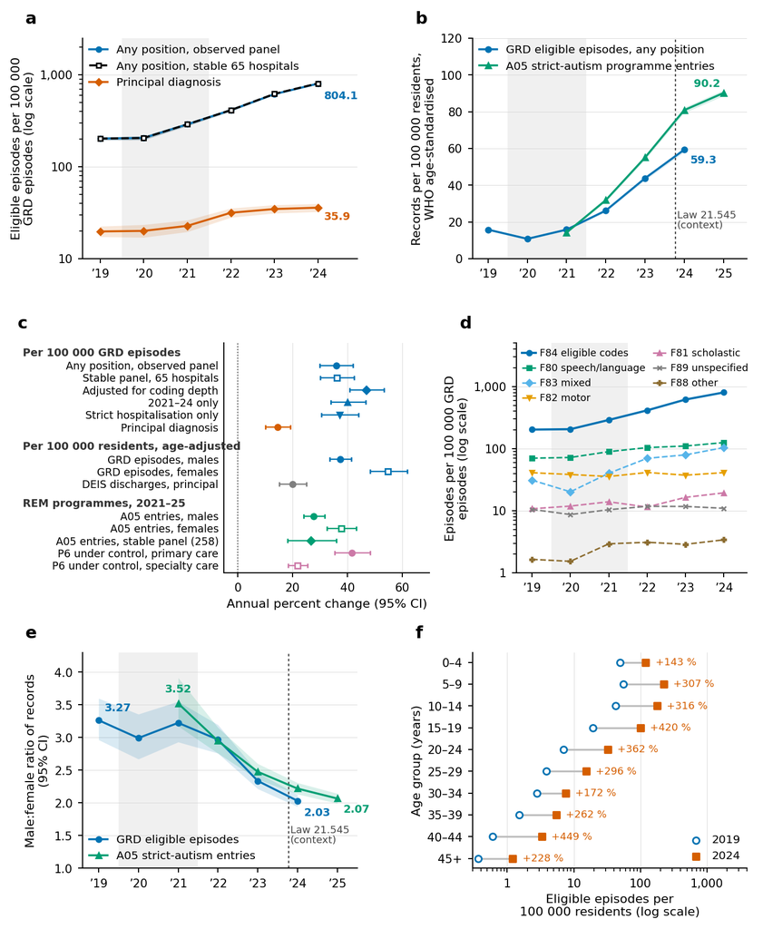

Figure 1. Drawn by the code above from the public tables in docs/study/data/.

```python
def fig1(lang):
    style(); fig = plt.figure(figsize=(175/25.4, 215/25.4))
    top = fig.add_gridspec(1, 2, left=0.115, right=0.985, top=0.97, bottom=0.735, wspace=0.42)
    mid = fig.add_gridspec(1, 2, left=0.30, right=0.985, top=0.645, bottom=0.40, wspace=0.40, width_ratios=[1, 1.12])
    bot = fig.add_gridspec(1, 2, left=0.115, right=0.985, top=0.315, bottom=0.085, wspace=0.42)
    g = load_grd_summary()
    obs = g.query("panel=='observed' and position=='any'").set_index('year').reindex(YRS_GRD)
    fix = g.query("panel=='fixed65' and position=='any'").set_index('year').reindex(YRS_GRD)
    pri = g.query("panel=='observed' and position=='principal'").set_index('year').reindex(YRS_GRD)
    # (a) primary indicator per 100 000 GRD episodes
    a = fig.add_subplot(top[0, 0]); clean(a); shade_pandemic(a)
    for z, col, mk, ls, lab in [(obs, BLUE, 'o', '-', text('Any position, observed panel', 'Cualquier posición, observados', lang)),
                                (fix, BLACK, 's', '--', text('Any position, stable 65 hospitals', 'Cualquier posición, 65 estables', lang)),
                                (pri, ORANGE, 'D', '-', text('Principal diagnosis', 'Diagnóstico principal', lang))]:
        a.fill_between(z.index, z.rate_lo, z.rate_hi, color=col, alpha=0.15, lw=0)
        a.plot(z.index, z.rate_per_100k_episodes, color=col, marker=mk, ls=ls, label=lab, mfc='white' if mk == 's' else col, ms=3.2)
    log_axis(a, 'y', lang); a.set_ylim(10, 2500); year_ticks(a, YRS_GRD, short=True)
    a.set_ylabel(text('Eligible episodes per 100 000\nGRD episodes (log scale)', 'Episodios elegibles por 100 000\nepisodios GRD (escala log)', lang))
    a.legend(loc='upper left', handlelength=1.6, borderaxespad=0.2)
    end_label(a, 2024, obs.rate_per_100k_episodes[2024], num(obs.rate_per_100k_episodes[2024], lang, 1), BLUE, dy=-8)
    end_label(a, 2024, pri.rate_per_100k_episodes[2024], num(pri.rate_per_100k_episodes[2024], lang, 1), ORANGE, dy=-6)
    a.set_xlim(2018.6, 2024.9)
    # (b) age-standardised indicators per 100 000 residents by source
    b = fig.add_subplot(top[0, 1]); clean(b); shade_pandemic(b)
    pr = pd.read_csv(TIDY/'models_population_rates.csv').query("variant=='sin_rett' and position=='any' and sex=='TOTAL'").set_index('year').reindex(YRS_GRD)
    a05 = pd.read_csv(DATA/'models_a05_standardised_rates.csv').query("variant=='strict_autism' and sex=='TOTAL'").set_index('year').reindex(YRS_REM)
    b.fill_between(pr.index, pr.asr_lo, pr.asr_hi, color=BLUE, alpha=0.15, lw=0)
    b.plot(pr.index, pr.asr, color=BLUE, marker='o', label=text('GRD eligible episodes, any position', 'Episodios GRD elegibles, cualquier posición', lang))
    b.fill_between(a05.index, a05.asr_lo, a05.asr_hi, color=GREEN, alpha=0.15, lw=0)
    b.plot(a05.index, a05.asr, color=GREEN, marker='^', label=text('A05 strict-autism programme entries', 'Ingresos A05 por autismo estricto', lang))
    law_line(b, lang, y=0.22)
    b.set_ylim(0, 120); b.set_xlim(2018.6, 2025.6); year_ticks(b, range(2019, 2026), short=True)
    b.set_ylabel(text('Records per 100 000 residents,\nWHO age-standardised', 'Registros por 100 000 residentes,\nestandarizados por edad (OMS)', lang))
    b.legend(loc='upper left', handlelength=1.6, borderaxespad=0.2)
    end_label(b, 2024, pr.asr[2024], num(pr.asr[2024], lang, 1), BLUE, dy=-7)
    end_label(b, 2025, a05.asr[2025], num(a05.asr[2025], lang, 1), GREEN, dy=6, ha='right', dx=-2)
    # (c) annual percent change forest (half width, short labels)
    c = fig.add_subplot(mid[0, 0]); clean(c, grid='x')
    rows = load_forest(); groups = {'grd': text('Per 100 000 GRD episodes', 'Por 100 000 episodios GRD', lang),
                                    'pop': text('Per 100 000 residents, age-adjusted', 'Por 100 000 residentes, ajustado por edad', lang),
                                    'rem': text('REM programmes, 2021–25', 'Programas REM, 2021–25', lang)}
    y = 0.0; ticks = []; labels = []; last = None
    for grp, en, es, (apc, lo, hi, df), col, mk in rows:
        if grp != last:
            y += 0.6; c.text(-0.98, y, groups[grp], transform=c.get_yaxis_transform(), fontsize=6.9, fontweight='bold', va='center', ha='left', color='#333333', clip_on=False); y += 1.0; last = grp
        c.errorbar(apc, y, xerr=[[apc - lo], [hi - apc]], fmt=mk, color=col, ms=3.6, capsize=1.6, lw=0.85, mfc=col if mk in 'oD^v' else 'white')
        ticks.append(y); labels.append(text(*SHORT[en], lang)); y += 1.0
    c.set_yticks(ticks); c.set_yticklabels(labels, fontsize=6.8); c.set_ylim(y - 0.4, -0.2); c.invert_yaxis() if False else None
    c.axvline(0, color='#555555', lw=0.7, ls=':'); c.set_xlim(-5, 70); c.set_xticks([0, 20, 40, 60])
    c.set_xlabel(text('Annual percent change (95% CI)', 'Cambio porcentual anual (IC 95%)', lang))
    c.tick_params(axis='y', length=0)
    # (d) F80–F89 block comparator, per 100 000 GRD episodes
    d = fig.add_subplot(mid[0, 1]); clean(d); shade_pandemic(d)
    f8 = pd.read_csv(DATA/'f80_f89_episode_rates.csv')
    panel = 'observed' if (f8.panel == 'observed').any() else 'fixed65'; f8 = f8[f8.panel == panel]
    # The block tabulation counts the whole F84 family (with F84.2); the eligible F84 line is drawn
    # from the sin_rett series of grd_year_summary on the same observed panel and denominator.
    tot = f8.query("category=='F84' and year==2024").n_episodes_total.iloc[0]
    assert panel == 'observed' and int(tot) == int(obs.n_episodes_total_same_panel_activity[2024]), (panel, tot)
    order = ['F84', 'F80', 'F83', 'F82', 'F81', 'F89', 'F88']
    cols = {'F84': BLUE, 'F80': GREEN, 'F83': SKY, 'F82': GOLD, 'F81': PINK, 'F89': GREY, 'F88': '#8c6d31'}
    mks = {'F84': 'o', 'F80': 's', 'F83': 'D', 'F82': 'v', 'F81': '^', 'F89': 'x', 'F88': 'P'}
    for cat in order:
        z = f8[f8.category == cat].set_index('year').reindex(YRS_GRD)
        if cat == 'F84': z = obs
        d.plot(z.index, z.rate_per_100k_episodes, color=cols[cat], marker=mks[cat], ls='-' if cat == 'F84' else '--', lw=1.4 if cat == 'F84' else 1.0, ms=3.2, label=text(*F8X_LABELS[cat], lang))
    log_axis(d, 'y', lang); d.set_ylim(1, 2000); d.set_xlim(2018.6, 2024.6); year_ticks(d, YRS_GRD, short=True)
    d.set_ylabel(text('Episodes per 100 000 GRD\nepisodes (log scale)', 'Episodios por 100 000\nepisodios GRD (escala log)', lang)); d.set_ylim(1, 5000)
    d.legend(loc='upper left', ncol=2, handlelength=1.4, columnspacing=0.7, handletextpad=0.4, borderaxespad=0.15, fontsize=6.4)
    # (e) male:female ratio
    e = fig.add_subplot(bot[0, 0]); clean(e)
    sr = pd.read_csv(DATA/'fig3d_sex_ratios.csv')
    for src, col, mk, lab in [('GRD', BLUE, 'o', text('GRD eligible episodes', 'Episodios GRD elegibles', lang)), ('A05', GREEN, '^', text('A05 strict-autism entries', 'Ingresos A05 autismo estricto', lang))]:
        z = sr[sr.source == src].sort_values('year')
        e.fill_between(z.year, z.ratio_lo, z.ratio_hi, color=col, alpha=0.15, lw=0)
        e.plot(z.year, z.male_female_count_ratio, color=col, marker=mk, label=lab)
        end_label(e, z.year.iloc[-1], z.male_female_count_ratio.iloc[-1], num(z.male_female_count_ratio.iloc[-1], lang, 2), col, dy=(-8 if src == 'GRD' else -7))
        end_label(e, z.year.iloc[0], z.male_female_count_ratio.iloc[0], num(z.male_female_count_ratio.iloc[0], lang, 2), col, dx=(4 if src == 'GRD' else 0), dy=(8 if src == 'GRD' else 9), ha=('left' if src == 'GRD' else 'center'))
    shade_pandemic(e); law_line(e, lang, y=0.20)
    e.set_ylim(1, 4.3); e.set_xlim(2018.6, 2025.5); year_ticks(e, range(2019, 2026), short=True)
    e.set_ylabel(text('Male:female ratio of records\n(95% CI)', 'Razón hombre:mujer de los\nregistros (IC 95%)', lang))
    e.legend(loc='lower left', handlelength=1.6, borderaxespad=0.2)
    # (f) age-specific GRD rates, 2019 vs 2024, both sexes
    f = fig.add_subplot(bot[0, 1]); clean(f, grid='x')
    ar = load_age_rates('grd', 2019, 2024); groups_age = list(ar[2019].index); ypos = np.arange(len(groups_age))
    for i, gname in enumerate(groups_age):
        r0, r1 = ar[2019].loc[gname], ar[2024].loc[gname]
        f.plot([r0.rate, r1.rate], [i, i], color=LIGHT, lw=1.2, zorder=1)
        pct = (r1.rate / r0.rate - 1) * 100
        f.text(max(r0.rate, r1.rate) * 1.4, i, ('+' if pct >= 0 else '−') + num(abs(pct), lang, 0) + ' %', va='center', fontsize=6.6, color=ORANGE if pct >= 0 else BLUE)
    f.scatter(ar[2019].rate, ypos, s=18, facecolors='white', edgecolors=BLUE, linewidths=1.1, zorder=3, label='2019')
    f.scatter(ar[2024].rate, ypos, s=18, color=ORANGE, marker='s', zorder=3, label='2024')
    log_axis(f, 'x', lang); f.set_xlim(0.3, 4000); f.set_yticks(ypos); f.set_yticklabels([s.replace('-', '–') for s in groups_age]); f.invert_yaxis()
    f.set_xlabel(text('Eligible episodes per\n100 000 residents (log scale)', 'Episodios elegibles por\n100 000 residentes (escala log)', lang))
    f.set_ylabel(text('Age group (years)', 'Grupo de edad (años)', lang))
    f.legend(loc='lower right', handlelength=1.2, borderaxespad=0.2)
    for ax, ch in zip([a, b, c, d, e, f], 'abcdef'): letter(fig, ax, ch, dx=(-0.27 if ch == 'c' else -0.075))
    save(fig, 'Figure_1', lang, close=False)
    return fig

plt.close(fig1('es'))          # Spanish plate: exported to docs/study/figures/es/
fig1('en')                     # English plate: exported and shown here
```

### Figure 2

**Show the code that produced this**

```
  Figure_2 [es] 175x215 mm; fonts 5.6–11.0 pt; off-canvas: 0; overlaps: 0
  Figure_2 [en] 175x215 mm; fonts 5.6–11.0 pt; off-canvas: 0; overlaps: 0
```

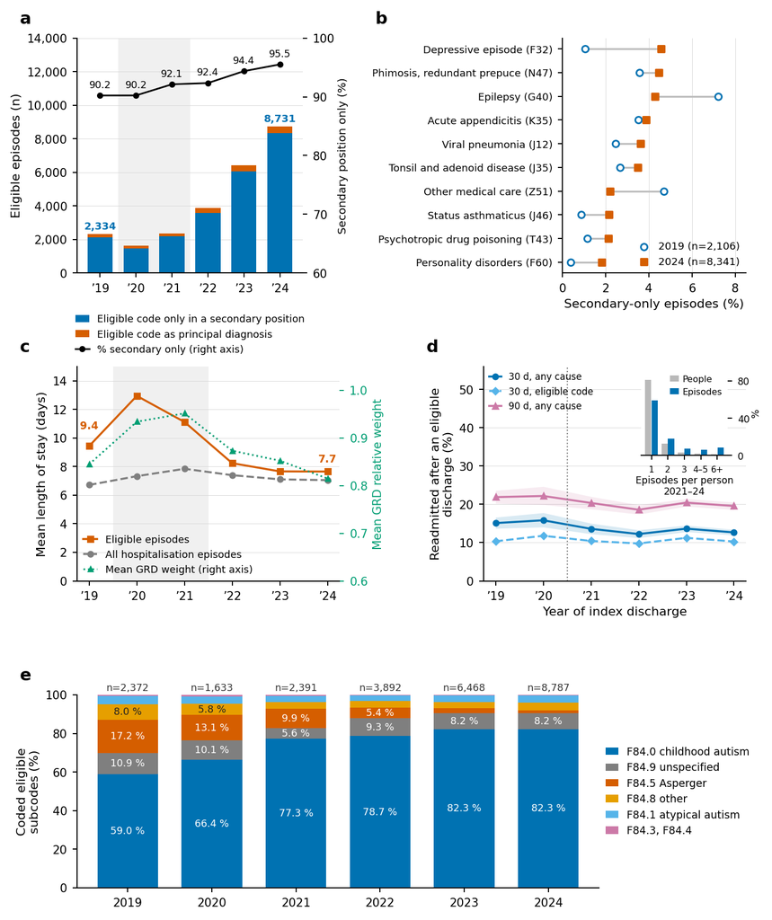

Figure 2. Drawn by the code above from the public tables in docs/study/data/.

```python
def fig2(lang):
    style(); fig = plt.figure(figsize=(175/25.4, 215/25.4))
    gs = fig.add_gridspec(3, 2, left=0.10, right=0.975, top=0.965, bottom=0.06, hspace=0.55, wspace=0.55, height_ratios=[1, 1, 0.9])
    top_a = fig.add_gridspec(1, 1, left=0.10, right=0.395, top=0.965, bottom=0.715)
    top_b = fig.add_gridspec(1, 1, left=0.735, right=0.975, top=0.965, bottom=0.715)
    g = load_grd_summary()
    obs = g.query("panel=='observed' and position=='any'").set_index('year').reindex(YRS_GRD)
    pri = g.query("panel=='observed' and position=='principal'").set_index('year').reindex(YRS_GRD)
    sec = g.query("panel=='observed' and position=='secondary_only'").set_index('year').reindex(YRS_GRD)
    # (a) diagnostic position of the eligible code
    a = fig.add_subplot(top_a[0, 0]); clean(a); shade_pandemic(a)
    a.bar(YRS_GRD, sec.n_episodes_f84, color=BLUE, width=0.7, label=text('Eligible code only in a secondary position', 'Código elegible solo en posición secundaria', lang), zorder=2)
    a.bar(YRS_GRD, pri.n_episodes_f84, bottom=sec.n_episodes_f84, color=ORANGE, width=0.7, label=text('Eligible code as principal diagnosis', 'Código elegible como diagnóstico principal', lang), zorder=2)
    a.yaxis.set_major_formatter(thousands(lang)); a.set_ylim(0, 14000); year_ticks(a, YRS_GRD, short=True)
    a.set_ylabel(text('Eligible episodes (n)', 'Episodios elegibles (n)', lang))
    a2 = a.twinx(); a2.grid(False); a2.spines['top'].set_visible(False)
    pct = sec.n_episodes_f84 / obs.n_episodes_f84 * 100
    a2.plot(YRS_GRD, pct, color=BLACK, marker='o', ms=3, lw=1.1, zorder=3, label=text('% secondary only (right axis)', '% solo secundaria (eje derecho)', lang))
    for yv, pv in zip(YRS_GRD, pct):
        a2.annotate(num(pv, lang, 1), (yv, pv), xytext=(0, 5), textcoords='offset points', ha='center', fontsize=6.4, color=BLACK)
    a2.set_ylim(60, 100); a2.set_yticks([60, 70, 80, 90, 100]); a2.set_ylabel(text('Secondary position only (%)', 'Solo posición secundaria (%)', lang), fontsize=7.2, labelpad=2)
    h1, l1 = a.get_legend_handles_labels(); h2, l2 = a2.get_legend_handles_labels()
    a.legend(h1 + h2, l1 + l2, loc='upper center', bbox_to_anchor=(0.5, -0.16), fontsize=6.5, handlelength=1.4, borderaxespad=0.0)
    for yv in [2019, 2024]:
        a.annotate(num(obs.n_episodes_f84[yv], lang, 0), (yv, obs.n_episodes_f84[yv]), xytext=(0, 3), textcoords='offset points', ha='center', fontsize=6.6, color=BLUE, fontweight='bold')
    # (b) principal diagnosis when the eligible code is secondary only, 2019 vs 2024
    b = fig.add_subplot(top_b[0, 0]); clean(b, grid='x')
    cp = pd.read_csv(DATA/'clinical_principal_selected.csv')
    order = cp[cp.year == 2024].sort_values('pct_of_f84_episodes', ascending=False).code3.tolist()
    ypos = np.arange(len(order))
    for i, code in enumerate(order):
        v0 = cp[(cp.code3 == code) & (cp.year == 2019)].pct_of_f84_episodes; v1 = cp[(cp.code3 == code) & (cp.year == 2024)].pct_of_f84_episodes
        v0 = float(v0.iloc[0]) if len(v0) else np.nan; v1 = float(v1.iloc[0]) if len(v1) else np.nan
        b.plot([v0, v1], [i, i], color=LIGHT, lw=1.2, zorder=1)
        b.scatter([v0], [i], s=18, facecolors='white', edgecolors=BLUE, linewidths=1.1, zorder=3)
        b.scatter([v1], [i], s=18, color=ORANGE, marker='s', zorder=3)
    n19 = int(cp[cp.year == 2019].n_f84_episodes_cell.iloc[0]); n24 = int(cp[cp.year == 2024].n_f84_episodes_cell.iloc[0])
    b.scatter([], [], s=18, facecolors='white', edgecolors=BLUE, linewidths=1.1, label=f'2019 (n={num(n19, lang)})')
    b.scatter([], [], s=18, color=ORANGE, marker='s', label=f'2024 (n={num(n24, lang)})')
    b.set_yticks(ypos); b.set_yticklabels([(ICD_EN if lang == 'en' else ICD_ES)[c] for c in order], fontsize=6.6); b.invert_yaxis()
    b.set_xlim(0, 8.5); b.set_xlabel(text('Secondary-only episodes (%)', 'Episodios solo secundarios (%)', lang))
    b.legend(loc='lower right', fontsize=6.6, handlelength=1.2, borderaxespad=0.2)
    # (c) length of stay and case-mix weight
    c = fig.add_subplot(gs[1, 0]); clean(c); shade_pandemic(c)
    st = pd.read_csv(DATA/'burden_length_of_stay.csv')
    c.plot(st.year, st.eligible_mean_days, color=ORANGE, marker='s', label=text('Eligible episodes', 'Episodios elegibles', lang))
    c.plot(st.year, st.all_mean_days, color=GREY, marker='o', ls='--', label=text('All hospitalisation episodes', 'Todos los episodios de hospitalización', lang))
    for j in (0, len(st) - 1):
        c.annotate(num(st.eligible_mean_days.iloc[j], lang, 1), (st.year.iloc[j], st.eligible_mean_days.iloc[j]), xytext=(0, 13) if j == 0 else (0, 6), textcoords='offset points', ha='center', va='center' if j == 0 else 'baseline', fontsize=6.8, color=ORANGE, fontweight='bold')
    c.set_ylim(0, 15); year_ticks(c, YRS_GRD, short=True); c.set_ylabel(text('Mean length of stay (days)', 'Estancia media (días)', lang))
    c2 = c.twinx(); c2.grid(False); c2.spines['top'].set_visible(False)
    c2.plot(st.year, st.eligible_mean_grd_weight, color=GREEN, marker='^', ls=':', lw=1.1, ms=3.2, label=text('Mean GRD weight (right axis)', 'Peso GRD medio (eje derecho)', lang))
    c2.set_ylim(0.6, 1.05); c2.set_ylabel(text('Mean GRD relative weight', 'Peso relativo GRD medio', lang), color=GREEN, fontsize=7.5); c2.tick_params(axis='y', colors=GREEN)
    h1, l1 = c.get_legend_handles_labels(); h2, l2 = c2.get_legend_handles_labels()
    c.legend(h1 + h2, l1 + l2, loc='lower left', fontsize=6.5, handlelength=1.4, borderaxespad=0.2)
    # (d) readmission and repeat contact
    d = fig.add_subplot(gs[1, 1]); clean(d)
    rd = pd.read_csv(TIDY/'grd_readmission.csv').query("variant=='sin_rett' and position=='any' and panel=='observed'")
    r30 = rd[rd.horizon_days == 30].set_index('year').reindex(YRS_GRD); r90 = rd[rd.horizon_days == 90].set_index('year').reindex(YRS_GRD)
    d.fill_between(r30.index, r30.pct_any_cause_lo, r30.pct_any_cause_hi, color=BLUE, alpha=0.15, lw=0)
    d.plot(r30.index, r30.pct_any_cause, color=BLUE, marker='o', label=text('30 d, any cause', '30 d, cualquier causa', lang))
    d.plot(r30.index, r30.pct_f84, color=SKY, marker='D', ls='--', ms=3, label=text('30 d, eligible code', '30 d, código elegible', lang))
    d.fill_between(r90.index, r90.pct_any_cause_lo, r90.pct_any_cause_hi, color=PINK, alpha=0.15, lw=0)
    d.plot(r90.index, r90.pct_any_cause, color=PINK, marker='^', label=text('90 d, any cause', '90 d, cualquier causa', lang))
    d.axvline(2020.5, color=GREY, ls=':', lw=0.8)
    d.set_ylim(0, 56); year_ticks(d, YRS_GRD, short=True); d.set_ylabel(text('Readmitted after an eligible\ndischarge (%)', 'Reingreso tras un egreso\nelegible (%)', lang))
    d.set_xlabel(text('Year of index discharge', 'Año del egreso índice', lang))
    d.legend(loc='upper left', fontsize=6.0, handlelength=1.3, borderaxespad=0.2, ncol=1)
    ins = d.inset_axes([0.60, 0.585, 0.33, 0.40]); ins.grid(False); ins.yaxis.tick_right(); ins.yaxis.set_label_position('right')
    mu = pd.read_csv(DATA/'burden_multiplicity.csv'); x = np.arange(len(mu))
    ins.bar(x - 0.2, mu.pct_persons, width=0.38, color='#b9b9b9', label=text('People', 'Personas', lang))
    ins.bar(x + 0.2, mu.pct_episodes, width=0.38, color=BLUE, label=text('Episodes', 'Episodios', lang))
    ins.set_xticks(x); ins.set_xticklabels([str(v).replace('-', '–') for v in mu.episodes_per_identifier], fontsize=5.6)
    ins.set_yticks([0, 40, 80]); ins.tick_params(axis='y', labelsize=6.2); ins.set_ylim(0, 92)
    ins.set_xlabel(text('Episodes per person\n2021–24', 'Episodios por persona\n2021–24', lang), fontsize=6.2, labelpad=1)
    ins.set_ylabel('%', fontsize=6.2, labelpad=1); ins.legend(fontsize=5.8, loc='upper right', handlelength=1, borderpad=0.1, handletextpad=0.4)
    for sp in ('top', 'left'): ins.spines[sp].set_visible(False)
    # (e) composition of the eligible F84 subcodes
    e = fig.add_subplot(gs[2, :]); clean(e, grid=None)
    sc = pd.read_csv(DATA/'case_definition_subcodes.csv').set_index('year').reindex(YRS_GRD)
    keys = ['F840', 'F849', 'F845', 'F848', 'F841', 'Other']; cols = [BLUE, GREY, ORANGE, GOLD, SKY, PINK]
    bottom = np.zeros(len(YRS_GRD))
    for k, col in zip(keys, cols):
        vals = sc['pct_' + k].values
        e.bar(YRS_GRD, vals, bottom=bottom, color=col, width=0.72, label=text(*SUB_LABELS[k], lang), zorder=2)
        for xi, (v, b0) in enumerate(zip(vals, bottom)):
            if v >= 4.5: e.text(YRS_GRD[xi], b0 + v / 2, num(v, lang, 1) + ' %', ha='center', va='center', fontsize=6.4, color='white' if col in (BLUE, GREY, ORANGE) else '#222222').set_gid('inbar')
        bottom += vals
    e.set_ylim(0, 100); e.set_ylabel(text('Coded eligible\nsubcodes (%)', 'Subcódigos elegibles\ncodificados (%)', lang)); year_ticks(e, YRS_GRD)
    tot = (sc[['F840', 'F841', 'F845', 'F848', 'F849', 'Other']].sum(axis=1)).astype(int)
    for xi, yv in enumerate(YRS_GRD): e.text(yv, 101, 'n=' + num(int(tot[yv]), lang), ha='center', va='bottom', fontsize=6.4, color='#333333')
    e.legend(loc='center left', bbox_to_anchor=(1.005, 0.5), fontsize=6.8, handlelength=1.2, borderaxespad=0.0)
    e.set_xlim(2018.4, 2024.6)
    pos = e.get_position(); e.set_position([pos.x0, pos.y0, pos.width * 0.78, pos.height])
    for ax, ch in zip([a, b, c, d, e], 'abcde'): letter(fig, ax, ch, dx=(-0.245 if ch == 'b' else -0.075))
    save(fig, 'Figure_2', lang, close=False)
    return fig

plt.close(fig2('es'))          # Spanish plate: exported to docs/study/figures/es/
fig2('en')                     # English plate: exported and shown here
```

### Figure 3

**Show the code that produced this**

```
  Figure_3 [es] 175x172 mm; fonts 5.8–11.0 pt; off-canvas: 0; overlaps: 0
  Figure_3 [en] 175x172 mm; fonts 5.8–11.0 pt; off-canvas: 0; overlaps: 0
```

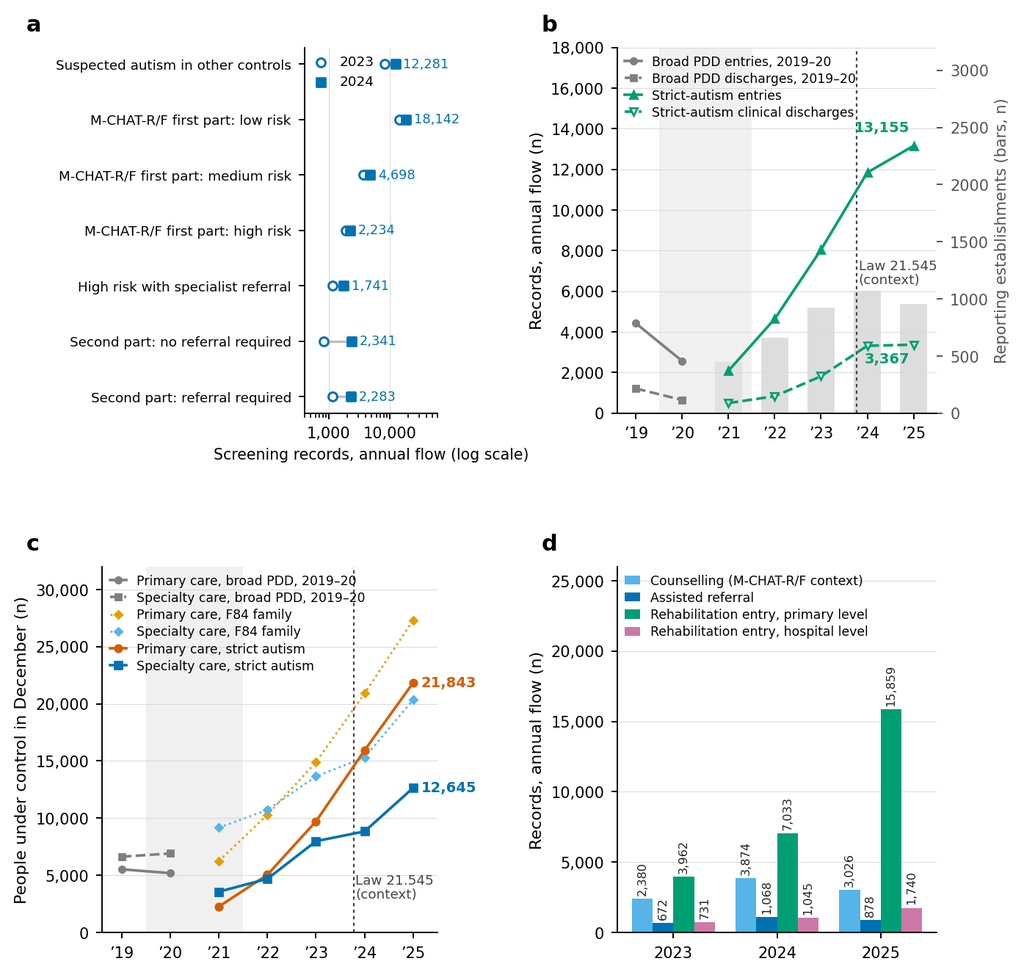

Figure 3. Drawn by the code above from the public tables in docs/study/data/.

```python
def fig3(lang):
    style(); fig = plt.figure(figsize=(175/25.4, 172/25.4))
    gs = fig.add_gridspec(2, 2, left=0.10, right=0.925, top=0.965, bottom=0.075, hspace=0.42, wspace=0.55, width_ratios=[1.05, 1])
    # (a) screening cascade, M-CHAT-R/F era (axes shifted right to make room for the category labels)
    a = fig.add_subplot(gs[0, 0]); clean(a, grid='x')
    pos = a.get_position(); a.set_position([pos.x0 + 0.20, pos.y0, pos.width - 0.20, pos.height])
    r = pd.read_csv(TIDY/'rem_pathway_annual.csv', low_memory=False); r['code'] = r.code.astype(str)
    ypos = np.arange(len(A03_ROWS))
    for i, (code, en, es) in enumerate(A03_ROWS):
        z = r[(r.code == code) & (r.variant == 'single_code')].set_index('year')
        v23 = float(z.total.get(2023, np.nan)); v24 = float(z.total.get(2024, np.nan))
        a.plot([v23, v24], [i, i], color=LIGHT, lw=1.2, zorder=1)
        a.scatter([v23], [i], s=18, facecolors='white', edgecolors=BLUE, linewidths=1.1, zorder=3)
        a.scatter([v24], [i], s=18, color=BLUE, marker='s', zorder=3)
        a.text(max(v23, v24) * 1.35, i, num(v24, lang), va='center', fontsize=6.4, color=BLUE)
    a.scatter([], [], s=18, facecolors='white', edgecolors=BLUE, linewidths=1.1, label='2023'); a.scatter([], [], s=18, color=BLUE, marker='s', label='2024')
    a.set_yticks(ypos); a.set_yticklabels([text(en, es, lang) for _, en, es in A03_ROWS], fontsize=6.6); a.invert_yaxis()
    log_axis(a, 'x', lang); a.set_xlim(400, 60000); a.set_xticks([1000, 10000]); a.xaxis.set_major_formatter(thousands(lang))
    a.set_xlabel(text('Screening records, annual flow (log scale)', 'Registros de tamizaje, flujo anual (escala log)', lang), fontsize=7.4)
    a.legend(loc='upper left', fontsize=6.6, handlelength=1.2, borderaxespad=0.2)
    # (b) A05 programme entries and clinical discharges, with reporting establishments
    b = fig.add_subplot(gs[0, 1]); clean(b); shade_pandemic(b)
    ent = rem_series('05990022'); dis = rem_series('05990027'); bent = rem_series('06902600'); bdis = rem_series('05225000')
    assert int(ent.total[2021]) == 2085 and int(ent.total[2025]) == 13155, ent.total.tolist()
    b2 = b.twinx(); b2.grid(False); b2.spines['top'].set_visible(False)
    for p_ in b2.bar(ent.index, ent.n_reporting_establishments, color='#dddddd', width=0.6, zorder=0): p_.set_gid('bg')
    b2.set_ylim(0, 3200); b2.set_ylabel(text('Reporting establishments (bars, n)', 'Establecimientos informantes (barras, n)', lang), fontsize=7.5, color='#555555'); b2.tick_params(axis='y', colors='#555555')
    b.set_zorder(b2.get_zorder() + 1); b.patch.set_visible(False)
    b.plot(bent.index, bent.total, color=GREY, marker='o', ls='-', ms=3, label=text('Broad PDD entries, 2019–20', 'Ingresos TGD amplio, 2019–20', lang))
    b.plot(bdis.index, bdis.total, color=GREY, marker='s', ls='--', ms=3, label=text('Broad PDD discharges, 2019–20', 'Egresos TGD amplio, 2019–20', lang))
    b.plot(ent.index, ent.total, color=GREEN, marker='^', label=text('Strict-autism entries', 'Ingresos por autismo estricto', lang))
    b.plot(dis.index, dis.total, color=GREEN, marker='v', ls='--', mfc='white', label=text('Strict-autism clinical discharges', 'Altas clínicas por autismo estricto', lang))
    end_label(b, 2025, ent.total[2025], num(ent.total[2025], lang), GREEN, dx=-2, dy=9, ha='right')
    end_label(b, 2025, dis.total[2025], num(dis.total[2025], lang), GREEN, dx=-2, dy=-7, ha='right')
    law_line(b, lang, y=0.42)
    b.set_ylim(0, 18000); b.yaxis.set_major_formatter(thousands(lang)); b.set_xlim(2018.6, 2025.5); year_ticks(b, range(2019, 2026), short=True)
    b.set_ylabel(text('Records, annual flow (n)', 'Registros, flujo anual (n)', lang))
    h1, l1 = b.get_legend_handles_labels(); h2, l2 = b2.get_legend_handles_labels()
    b.legend(h1 + h2, l1 + l2, loc='upper left', fontsize=6.2, handlelength=1.3, borderaxespad=0.2, labelspacing=0.3)
    # (c) people under control in December, P6, by level of care
    c = fig.add_subplot(gs[1, 0]); clean(c); shade_pandemic(c)
    pp = rem_series('P6241010', measure='december_stock'); ps = rem_series('P6241060', measure='december_stock')
    fp = rem_series('P6241010+P6241020+P6241040+P6241050', variant='sin_rett', measure='december_stock'); fs = rem_series('P6241060+P6241070+P6241090+P6241100', variant='sin_rett', measure='december_stock')
    bp = rem_series('P6223000', measure='december_stock'); bs = rem_series('P6223380', measure='december_stock')
    c.plot(bp.index, bp.total, color=GREY, marker='o', ms=3, label=text('Primary care, broad PDD, 2019–20', 'APS, TGD amplio, 2019–20', lang))
    c.plot(bs.index, bs.total, color=GREY, marker='s', ms=3, ls='--', label=text('Specialty care, broad PDD, 2019–20', 'Especialidad, TGD amplio, 2019–20', lang))
    c.plot(fp.index, fp.total, color=GOLD, marker='D', ms=2.8, ls=':', lw=1.0, label=text('Primary care, F84 family', 'APS, familia F84', lang))
    c.plot(fs.index, fs.total, color=SKY, marker='D', ms=2.8, ls=':', lw=1.0, label=text('Specialty care, F84 family', 'Especialidad, familia F84', lang))
    c.plot(pp.index, pp.total, color=ORANGE, marker='o', label=text('Primary care, strict autism', 'APS, autismo estricto', lang))
    c.plot(ps.index, ps.total, color=BLUE, marker='s', label=text('Specialty care, strict autism', 'Especialidad, autismo estricto', lang))
    end_label(c, 2025, pp.total[2025], num(pp.total[2025], lang), ORANGE, dx=4)
    end_label(c, 2025, ps.total[2025], num(ps.total[2025], lang), BLUE, dx=4)
    law_line(c, lang, y=0.16)
    c.set_ylim(0, 32000); c.yaxis.set_major_formatter(thousands(lang)); c.set_xlim(2018.6, 2025.5); year_ticks(c, range(2019, 2026), short=True)
    c.set_ylabel(text('People under control in December (n)', 'Personas en control en diciembre (n)', lang))
    c.legend(loc='upper left', fontsize=6.2, handlelength=1.3, borderaxespad=0.2, labelspacing=0.3)
    # (d) counselling, assisted referral and rehabilitation entries, 2023–2025
    d = fig.add_subplot(gs[1, 1]); clean(d)
    items = [('29101566', 'Counselling (M-CHAT-R/F context)', 'Consejería (contexto M-CHAT-R/F)', SKY),
             ('29101574', 'Assisted referral', 'Derivación asistida', BLUE),
             ('29101629', 'Rehabilitation entry, primary level', 'Ingreso a rehabilitación, nivel primario', GREEN),
             ('29101651', 'Rehabilitation entry, hospital level', 'Ingreso a rehabilitación, nivel hospitalario', PINK)]
    yrs = [2023, 2024, 2025]; w = 0.2
    for j, (code, en, es, col) in enumerate(items):
        z = rem_series(code).reindex(yrs)
        xs = np.array(yrs) + (j - 1.5) * w
        d.bar(xs, z.total, width=w, color=col, label=text(en, es, lang), zorder=2)
        for x, v, n in zip(xs, z.total, z.n_reporting_establishments):
            d.text(x, v + 250, num(v, lang), ha='center', va='bottom', fontsize=5.8, color='#222222', rotation=90)
    d.set_xticks(yrs); d.set_ylim(0, 26000); d.yaxis.set_major_formatter(thousands(lang))
    d.set_ylabel(text('Records, annual flow (n)', 'Registros, flujo anual (n)', lang))
    d.legend(loc='upper left', fontsize=6.2, handlelength=1.2, borderaxespad=0.2, labelspacing=0.3)
    for ax, ch in zip([a, b, c, d], 'abcd'): letter(fig, ax, ch, dx=(-0.275 if ch == 'a' else -0.075))
    save(fig, 'Figure_3', lang, close=False)
    return fig

plt.close(fig3('es'))          # Spanish plate: exported to docs/study/figures/es/
fig3('en')                     # English plate: exported and shown here
```

### Figure 4

**Show the code that produced this**

```
  Figure_4 [es] 175x172 mm; fonts 6.2–11.0 pt; off-canvas: 0; overlaps: 0
  Figure_4 [en] 175x172 mm; fonts 6.2–11.0 pt; off-canvas: 0; overlaps: 0
```

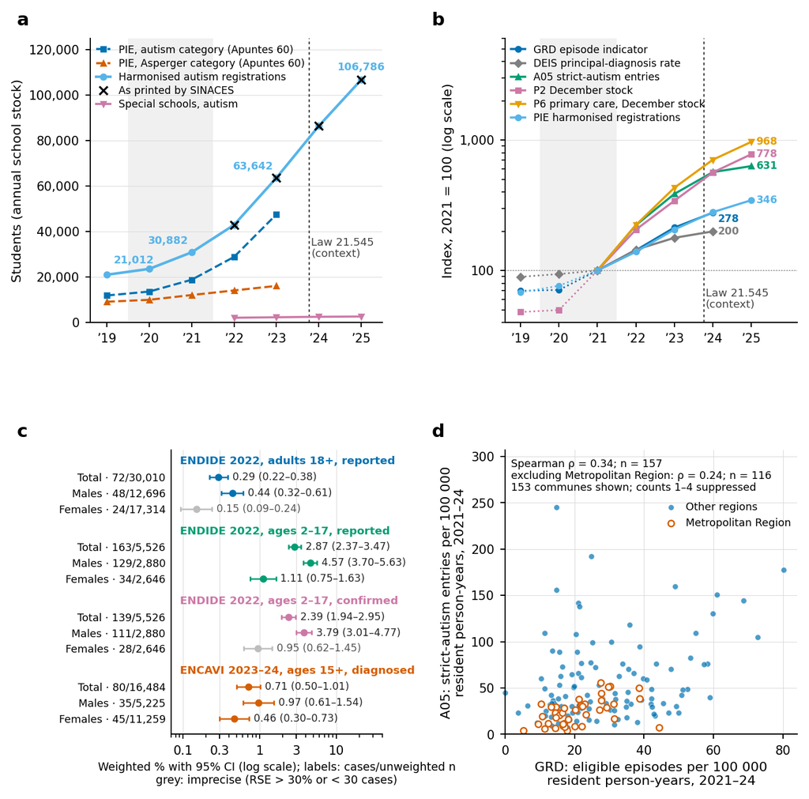

Figure 4. Drawn by the code above from the public tables in docs/study/data/.

```python
def fig4(lang):
    style(); fig = plt.figure(figsize=(175/25.4, 172/25.4))
    gs = fig.add_gridspec(2, 2, left=0.105, right=0.975, top=0.965, bottom=0.095, hspace=0.45, wspace=0.42)
    # (a) educational registrations
    a = fig.add_subplot(gs[0, 0]); clean(a); shade_pandemic(a)
    pie = pd.read_csv(TIDY/'education_summary_year.csv').set_index('year')   # same series as fig3a_pie.csv, plus special schools
    a.plot(pie.index, pie.pie_tea_strict_n, color=BLUE, marker='s', ls='--', ms=3, label=text('PIE, autism category (Apuntes 60)', 'PIE, categoría autismo (Apuntes 60)', lang))
    a.plot(pie.index, pie.pie_tea_asperger_n, color=ORANGE, marker='^', ls='--', ms=3, label=text('PIE, Asperger category (Apuntes 60)', 'PIE, categoría Asperger (Apuntes 60)', lang))
    a.plot(pie.index, pie.pie_harmonised_n, color=SKY, marker='o', lw=1.6, label=text('Harmonised autism registrations', 'Registros armonizados de autismo', lang))
    sin = pie.pie_harmonised_sinaces_n.dropna()
    a.plot(sin.index, sin.values, color=BLACK, marker='x', ls='none', ms=5, mew=1.2, label=text('As printed by SINACES', 'Según SINACES', lang))
    a.plot(pie.index, pie.special_schools_autism_n, color=PINK, marker='v', ms=3, label=text('Special schools, autism', 'Escuelas especiales, autismo', lang))
    for yv in [2019, 2021, 2023, 2025]:
        v = pie.pie_harmonised_n[yv]; a.annotate(num(v, lang), (yv, v), xytext=((4, 7) if yv == 2019 else ((0, 6) if yv == 2025 else (-2, 5))), textcoords='offset points', ha=('left' if yv == 2019 else ('center' if yv == 2025 else 'right')), fontsize=6.4, color=SKY, fontweight='bold')
    law_line(a, lang, y=0.30)
    a.set_ylim(0, 125000); a.yaxis.set_major_formatter(thousands(lang)); a.set_xlim(2018.6, 2025.5); year_ticks(a, range(2019, 2026), short=True)
    a.set_ylabel(text('Students (annual school stock)', 'Estudiantes (stock escolar anual)', lang))
    a.legend(loc='upper left', fontsize=6.2, handlelength=1.4, borderaxespad=0.2, labelspacing=0.3)
    # (b) relative change across systems, 2021 = 100
    b = fig.add_subplot(gs[0, 1]); clean(b); shade_pandemic(b)
    ci = pd.read_csv(TIDY/'models_convergence_index.csv').query("variant=='sin_rett' and index_base_year==2021")
    series = [('grd_any_rate', 'GRD episode indicator', 'Indicador de episodios GRD', BLUE, 'o', '-'),
              ('deis_principal_rate', 'DEIS principal-diagnosis rate', 'Tasa DEIS diagnóstico principal', GREY, 'D', '-'),
              ('a05_strict_entries', 'A05 strict-autism entries', 'Ingresos A05 autismo estricto', GREEN, '^', '-'),
              ('p2_december_stock', 'P2 December stock', 'Stock P2 de diciembre', PINK, 's', '-'),
              ('p6_primary_strict_stock', 'P6 primary care, December stock', 'P6 APS, stock de diciembre', GOLD, 'v', '-'),
              ('pie_harmonised', 'PIE harmonised registrations', 'Registros PIE armonizados', SKY, 'o', '-')]
    for key, en, es, col, mk, ls in series:
        z = ci[ci.series == key].set_index('year').sort_index()
        pre = z[z.index <= 2021]; post = z[z.index >= 2021]
        if len(pre) > 1: b.plot(pre.index, pre['index'], color=col, marker=mk, ls=':', ms=3, lw=1)
        b.plot(post.index, post['index'], color=col, marker=mk, ls=ls, ms=3.2, label=text(en, es, lang))
        end_label(b, post.index[-1], post['index'].iloc[-1], num(post['index'].iloc[-1], lang), col, dx=3, dy=(-4 if key == 'grd_any_rate' else 0), size=6.2)
    b.axhline(100, color='#8c8c8c', lw=0.6, ls=':'); law_line(b, lang, y=0.12)
    log_axis(b, 'y', lang); b.set_ylim(40, 6000); b.set_xlim(2018.6, 2026.2); year_ticks(b, range(2019, 2026), short=True)
    b.set_ylabel(text('Index, 2021 = 100 (log scale)', 'Índice, 2021 = 100 (escala log)', lang))
    b.legend(loc='upper left', fontsize=6.2, handlelength=1.4, borderaxespad=0.2, labelspacing=0.3)
    # (c) population surveys
    c = fig.add_subplot(gs[1, 0]); clean(c, grid='x')
    pos = c.get_position(); c.set_position([pos.x0 + 0.10, pos.y0, pos.width - 0.10, pos.height])
    sv = pd.read_csv(TIDY/'survey_estimates.csv').query("estimate_type=='primary' and subgroup_type in ('total','sex')")
    blocks = [('ENDIDE adultos 18+: autismo reportado', 'ENDIDE 2022, adults 18+, reported', 'ENDIDE 2022, adultos 18+, reportado', BLUE),
              ('ENDIDE NNA 2-17: autismo reportado', 'ENDIDE 2022, ages 2–17, reported', 'ENDIDE 2022, 2–17 años, reportado', GREEN),
              ('ENDIDE NNA 2-17: autismo reportado y confirmado por un médico', 'ENDIDE 2022, ages 2–17, confirmed', 'ENDIDE 2022, 2–17 años, confirmado', PINK),
              ('ENCAVI 15+: diagnóstico de trastorno del espectro autista', 'ENCAVI 2023–24, ages 15+, diagnosed', 'ENCAVI 2023–24, 15+ años, diagnóstico', ORANGE)]
    sub_lab = {'total': text('Total', 'Total', lang), 'Hombre': text('Males', 'Hombres', lang), 'Mujer': text('Females', 'Mujeres', lang)}
    y = 0; ticks = []; labels = []
    for dom, en, es, col in blocks:
        c.text(0.04, y, text(en, es, lang), fontsize=6.6, fontweight='bold', color=col, va='center', ha='left', transform=c.get_yaxis_transform()); y += 1
        for sub in ['total', 'Hombre', 'Mujer']:
            r = sv[(sv.domain == dom) & (sv.subgroup == sub)].iloc[0]
            est, lo, hi = r.proportion * 100, r.lo * 100, r.hi * 100
            imp = str(r.precision_flag) != 'adequate'
            c.errorbar(est, y, xerr=[[est - lo], [hi - est]], fmt='o', color=LIGHT if imp else col, ms=3.4, capsize=1.6, lw=0.9)
            c.text(hi * 1.15, y, f'{num(est, lang, 2)} ({num(lo, lang, 2)}–{num(hi, lang, 2)})', va='center', fontsize=6.2, color='#555555' if imp else '#222222')
            ticks.append(y); labels.append(f'{sub_lab[sub]} · {int(r.cases)}/{num(int(r.n), lang)}'); y += 1
        y += 0.4
    c.set_yticks(ticks); c.set_yticklabels(labels, fontsize=6.4); c.set_ylim(y - 0.4, -0.7); c.tick_params(axis='y', length=0)
    log_axis(c, 'x', lang); c.set_xlim(0.07, 40); c.set_xticks([0.1, 0.3, 1, 3, 10]); c.xaxis.set_major_formatter(FuncFormatter(lambda v, p: num(v, lang, 1) if v < 1 else num(v, lang, 0)))
    c.set_xlabel(text('Weighted % with 95% CI (log scale); labels: cases/unweighted n\ngrey: imprecise (RSE > 30% or < 30 cases)', '% ponderado con IC 95% (escala log); etiquetas: casos/n sin ponderar\ngris: impreciso (RSE > 30% o < 30 casos)', lang), fontsize=6.8)
    # (d) commune-level comparison between hospital and programme indicators, 2021–2024
    d = fig.add_subplot(gs[1, 1]); clean(d, grid='both')
    # Public extract: rates of communes whose GRD and A05 counts are 0 or >= 5 (cells 1-4 masked); no identifiers.
    base = pd.read_csv(DATA/'communes_public.csv'); corr = pd.read_csv(DATA/'S4_correlations_selected_sensitivities.csv')
    z = base.dropna(subset=['GRD', 'A05'])
    rm = z.metropolitan.astype(bool)
    d.scatter(z.GRD[~rm], z.A05[~rm], s=12, color=BLUE, alpha=0.7, edgecolors='white', linewidths=0.3, label=text('Other regions', 'Otras regiones', lang), clip_on=False)
    d.scatter(z.GRD[rm], z.A05[rm], s=14, facecolors='white', edgecolors=ORANGE, linewidths=0.9, label=text('Metropolitan Region', 'Región Metropolitana', lang), clip_on=False)
    r = corr[(corr.pair == 'GRD–A05') & (corr.scope == 'commune') & (corr.analysis == 'core')].iloc[0]
    rx = corr[(corr.pair == 'GRD–A05') & (corr.scope == 'commune') & (corr.analysis == 'exclude_metropolitan')].iloc[0]
    d.text(0.02, 0.97, text(f'Spearman ρ = {num(r.rho, lang, 2)}; n = {int(r.n)}\nexcluding Metropolitan Region: ρ = {num(rx.rho, lang, 2)}; n = {int(rx.n)}\n{len(z)} communes shown; counts 1–4 suppressed',
                            f'ρ de Spearman = {num(r.rho, lang, 2)}; n = {int(r.n)}\nsin Región Metropolitana: ρ = {num(rx.rho, lang, 2)}; n = {int(rx.n)}\n{len(z)} comunas visibles; recuentos 1–4 suprimidos', lang),
           transform=d.transAxes, va='top', ha='left', fontsize=6.4, linespacing=1.15)
    d.set_xlabel(text('GRD: eligible episodes per 100 000\nresident person-years, 2021–24', 'GRD: episodios elegibles por 100 000\npersonas-año residentes, 2021–24', lang))
    d.set_ylabel(text('A05: strict-autism entries per 100 000\nresident person-years, 2021–24', 'A05: ingresos autismo estricto por 100 000\npersonas-año residentes, 2021–24', lang))
    d.set_xlim(left=0); d.set_ylim(0, float(z.A05.max()) * 1.25)
    d.legend(loc='upper right', bbox_to_anchor=(1.0, 0.84), fontsize=6.4, handlelength=1.2, borderaxespad=0.2)
    for ax, ch in zip([a, b, c, d], 'abcd'): letter(fig, ax, ch, dx=(-0.19 if ch == 'c' else -0.09))
    save(fig, 'Figure_4', lang, close=False)
    return fig

plt.close(fig4('es'))          # Spanish plate: exported to docs/study/figures/es/
fig4('en')                     # English plate: exported and shown here
```

## Supplementary figures

### Figure S1

**Show the code that produced this**

```
  Figure_S1 [es] 175x190 mm; fonts 6.8–11.0 pt; off-canvas: 0; overlaps: 0
  Figure_S1 [en] 175x190 mm; fonts 6.8–11.0 pt; off-canvas: 0; overlaps: 0
```

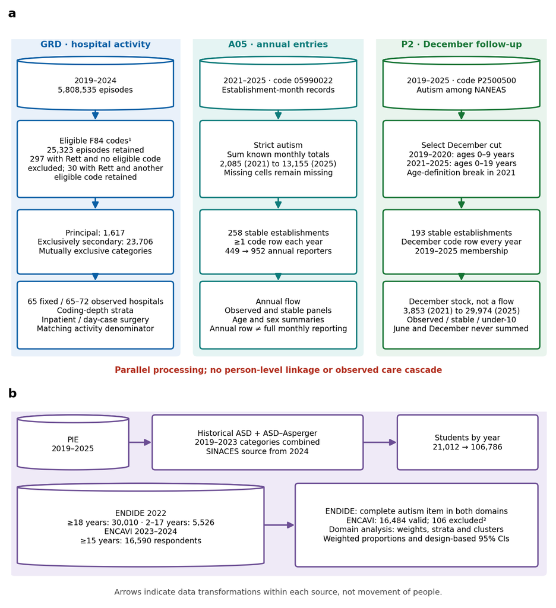

Figure S1. Drawn by the code above from the public tables in docs/study/data/.

```python
def figS1(lang):
    style(); fig = plt.figure(figsize=(S1_W/300, S1_H/300))
    axa = fig.add_axes([0.018, 0.417, 0.964, 0.530]); axb = fig.add_axes([0.018, 0.054, 0.964, 0.277])
    for ax in (axa, axb): ax.set_axis_off(); ax.grid(False); ax.set_xlim(0, 1); ax.set_ylim(0, 1)

    # ---- every number of the schematic, recomputed from the tracked tables -------------------
    g = pd.read_csv(TIDY/'grd_year_summary.csv').query("panel=='observed' and activity=='all'")
    gany = g.query("variant=='sin_rett' and position=='any'")
    tot = int(gany.n_episodes_total_same_panel_activity.sum())
    anys = int(gany.n_episodes_f84.sum())
    rett_only = int(g.query("variant=='con_rett' and position=='any'").n_episodes_f84.sum()) - anys
    prin = int(g.query("variant=='sin_rett' and position=='principal'").n_episodes_f84.sum())
    sec = int(g.query("variant=='sin_rett' and position=='secondary_only'").n_episodes_f84.sum())
    st = pd.read_csv(CORPUS/'ST10_grd_f84_subcodes.csv')
    yr0, yr1 = int(gany.year.min()), int(gany.year.max())
    rett_any = int(st[st['ICD-10 subcode'].str.startswith('F84.2') & (st['F84 code position'] == 'Any position')]
                   [[str(y) for y in range(yr0, yr1 + 1)]].iloc[0].astype(str).str.replace(',', '').astype(int).sum())
    rett_kept = rett_any - rett_only
    hosp = gany.set_index('year').hospitals_n
    fixed = int(pd.read_csv(TIDY/'grd_year_summary.csv')
                .query("panel=='fixed65' and activity=='all' and position=='any' and variant=='sin_rett'").hospitals_n.max())

    rp = pd.read_csv(TIDY/'rem_pathway_annual.csv', low_memory=False); rp['code'] = rp.code.astype(str)
    a05 = rp.query("module=='A05' and code=='05990022' and variant=='single_code'").set_index('year').sort_index()
    p2 = rp.query("module=='P2' and code=='P2500500' and measure=='december_stock'").set_index('year').sort_index()
    a_y0, a_y1 = int(a05.era_start.iloc[0]), int(a05.era_end.iloc[0])
    p_y0, p_y1 = int(p2.era_start.iloc[0]), int(p2.era_end.iloc[0])
    a_stable = int(a05.n_stable_panel_establishments.max()); p_stable = int(p2.n_stable_panel_establishments.max())
    a_rep0, a_rep1 = int(a05.n_reporting_establishments.iloc[0]), int(a05.n_reporting_establishments.iloc[-1])
    a_t0, a_t1 = int(a05.total.iloc[0]), int(a05.total.iloc[-1])
    # The plate quotes the P2 stock from the 2021 age-definition break, not from era_start (2019).
    # Like the age lines of box 2, that break year lives only in contenido_v10.json, not in a tracked CSV.
    p_yA = 2021
    p_tA, p_t1 = int(p2.total.loc[p_yA]), int(p2.total.iloc[-1])

    ed = pd.read_csv(TIDY/'education_summary_year.csv').set_index('year')
    pie = ed[ed.pie_harmonised_n.notna()]
    e_y0, e_y1 = int(pie.index.min()), int(pie.index.max())
    split = ed[ed.pie_tea_strict_n.notna() & ed.pie_tea_asperger_n.notna()].index
    s_y0, s_y1 = int(split.min()), int(split.max())
    sinaces = int(ed.index[ed.pie_harmonised_source.fillna('').str.contains('SINACES')].min())
    e_n0, e_n1 = int(pie.pie_harmonised_n.iloc[0]), int(pie.pie_harmonised_n.iloc[-1])

    sv = pd.read_csv(TIDY/'survey_estimates.csv'); tot_rows = sv[sv.subgroup_type == 'total']
    endide = tot_rows[tot_rows.survey.str.startswith('ENDIDE')]
    n_ad = int(endide[(endide.module == 'Adultos (18+)') & (endide.estimate_type == 'primary')].n.iloc[0])
    n_nna = int(endide[endide.module.str.startswith('NNA (2-17)') &
                       (endide.domain == 'ENDIDE NNA 2-17: autismo reportado')].n.iloc[0])
    encavi = tot_rows[tot_rows.survey.str.startswith('ENCAVI')]
    n_val = int(encavi[encavi.estimate_type == 'primary'].n.iloc[0])
    n_base = int(encavi[encavi.estimate_type == 'sensitivity'].n.iloc[0])
    n_exc = n_base - n_val
    endide_lbl = endide.survey.iloc[0].replace('-', '–'); encavi_lbl = encavi.survey.iloc[0].replace('-', '–')

    # ---- panel (a): the three administrative sources, processed in parallel -------------------
    bands = [('grd', 38, 670), ('a05', 716, 1350), ('p2', 1396, 2030)]
    heads = [text('GRD · hospital activity', 'GRD · actividad hospitalaria', lang),
             text('A05 · annual entries', 'A05 · ingresos anuales', lang),
             text('P2 · December follow-up', 'P2 · seguimiento en diciembre', lang)]
    cyls = [[f'{yr0}–{yr1}', f"{num(tot, lang)} {text('episodes', 'episodios', lang)}"],
            [f"{a_y0}–{a_y1} · {text('code', 'código', lang)} 05990022",
             text('Establishment-month records', 'Registros establecimiento-mes', lang)],
            [f"{p_y0}–{p_y1} · {text('code', 'código', lang)} P2500500",
             text('Autism among NANEAS', 'Autismo en NANEAS', lang)]]
    box2 = [[text('Eligible F84 codes¹', 'Códigos F84 elegibles¹', lang),
             f"{num(anys, lang)} {text('episodes retained', 'episodios incluidos', lang)}",
             f"{num(rett_only, lang)} {text('with Rett and no eligible code', 'con Rett sin código elegible', lang)}",
             text(f'excluded; {num(rett_kept, lang)} with Rett and another',
                  f'excluidos; {num(rett_kept, lang)} con Rett y otro', lang),
             text('eligible code retained', 'código elegible incluidos', lang)],
            [text('Strict autism', 'Autismo estricto', lang),
             text('Sum known monthly totals', 'Sumar totales mensuales conocidos', lang),
             f"{num(a_t0, lang)} ({a_y0}) {text('to', 'a', lang)} {num(a_t1, lang)} ({a_y1})",
             text('Missing cells remain missing', 'Celdas vacías siguen faltantes', lang)],
            # The P2 age universe is stored only as text (contenido_v10.json, manuscript Table 2 and
            # supplement Table S1); no tracked CSV carries it as a value, so it is written out here.
            [text('Select December cut', 'Seleccionar corte de diciembre', lang),
             text('2019–2020: ages 0–9 years', '2019–2020: 0–9 años', lang),
             text('2021–2025: ages 0–19 years', '2021–2025: 0–19 años', lang),
             text('Age-definition break in 2021', 'Quiebre de edad en 2021', lang)]]
    box3 = [[f"Principal: {num(prin, lang)}",
             f"{text('Exclusively secondary', 'Solo secundario', lang)}: {num(sec, lang)}",
             text('Mutually exclusive categories', 'Categorías excluyentes', lang)],
            [f"{num(a_stable, lang)} {text('stable establishments', 'establecimientos estables', lang)}",
             text('≥1 code row each year', '≥1 fila del código cada año', lang),
             f"{num(a_rep0, lang)} → {num(a_rep1, lang)} {text('annual reporters', 'reportantes anuales', lang)}"],
            [f"{num(p_stable, lang)} {text('stable establishments', 'establecimientos estables', lang)}",
             text('December code row every year', 'Fila del código cada diciembre', lang),
             text(f'{p_y0}–{p_y1} membership', f'Pertenencia durante {p_y0}–{p_y1}', lang)]]
    box4 = [[text(f'{num(fixed, lang)} fixed / {num(hosp.min(), lang)}–{num(hosp.max(), lang)} observed hospitals',
                  f'{num(fixed, lang)} hospitales fijos / {num(hosp.min(), lang)}–{num(hosp.max(), lang)} observados', lang),
             text('Coding-depth strata', 'Estratos de profundidad de códigos', lang),
             text('Inpatient / day-case surgery', 'Hospitalización / cirugía ambulatoria', lang),
             text('Matching activity denominator', 'Denominador de actividad propio', lang)],
            [text('Annual flow', 'Flujo anual', lang),
             text('Observed and stable panels', 'Paneles observado y estable', lang),
             text('Age and sex summaries', 'Resúmenes por edad y sexo', lang),
             text('Annual row ≠ full monthly reporting', 'Fila anual ≠ reporte mensual completo', lang)],
            [text('December stock, not a flow', 'Stock de diciembre, no flujo', lang),
             f"{num(p_tA, lang)} ({p_yA}) {text('to', 'a', lang)} {num(p_t1, lang)} ({p_y1})",
             text('Observed / stable / under-10', 'Observado / estable / menores de 10', lang),
             text('June and December never summed', 'Junio y diciembre no se suman', lang)]]
    rows = [(197, 396), (435, 721), (766, 1005), (1032, 1283)]
    for i, (key, bx0, bx1) in enumerate(bands):
        ec, fcb = S1_COLOURS[key]; cx = (bx0 + bx1)/2
        _s1_box(fig, axa, bx0, 118, bx1, 1311, 'none', fc=fcb, lw=0, r=0.05)
        _s1_lines(fig, axa, cx, 153, [heads[i]], size=7.8, color=ec, weight='bold')
        yc = _s1_cyl(fig, axa, bx0 + 26, rows[0][0], bx1 - 26, rows[0][1], ec)
        _s1_lines(fig, axa, cx, yc, cyls[i])
        for (y0, y1), lines in zip(rows[1:], (box2[i], box3[i], box4[i])):
            _s1_box(fig, axa, bx0 + 26, y0, bx1 - 26, y1, ec)
            _s1_lines(fig, axa, cx, (y0 + y1)/2, lines)
        for (ya, yb) in ((rows[0][1] + 2, rows[1][0] - 2), (rows[1][1] + 2, rows[2][0] - 2), (rows[2][1] + 2, rows[3][0] - 2)):
            _s1_arrow(fig, axa, cx, ya, cx, yb, ec)
    _s1_lines(fig, axa, S1_W/2, 1362,
              [text('Parallel processing; no person-level linkage or observed care cascade',
                    'Procesamiento paralelo; sin enlace individual ni cascada asistencial observada', lang)],
              size=7.4, color=S1_RED, weight='bold')

    # ---- panel (b): education records and the two household surveys --------------------------
    ec, fcb = S1_COLOURS['b']
    _s1_box(fig, axb, 38, 1500, 2030, 2126, 'none', fc=fcb, lw=0, r=0.05)
    yc = _s1_cyl(fig, axb, 64, 1528, 478, 1732, ec, ry=14.5)
    _s1_lines(fig, axb, 271, yc, ['PIE', f'{e_y0}–{e_y1}'])
    _s1_box(fig, axb, 565, 1528, 1348, 1732, ec)
    _s1_lines(fig, axb, 956, 1630, [text('Historical ASD + ASD–Asperger', 'TEA + TEA–Asperger históricos', lang),
                                    text(f'{s_y0}–{s_y1} categories combined', f'Categorías {s_y0}–{s_y1} combinadas', lang),
                                    text(f'SINACES source from {sinaces}', f'Fuente SINACES desde {sinaces}', lang)])
    _s1_box(fig, axb, 1475, 1528, 1997, 1732, ec)
    _s1_lines(fig, axb, 1736, 1630, [text('Students by year', 'Estudiantes por año', lang),
                                     f'{num(e_n0, lang)} → {num(e_n1, lang)}'])
    yc = _s1_cyl(fig, axb, 64, 1782, 980, 2092, ec, ry=14.5)
    _s1_lines(fig, axb, 522, yc, [endide_lbl,
                                  f"≥18 {text('years', 'años', lang)}: {num(n_ad, lang)} · 2–17 {text('years', 'años', lang)}: {num(n_nna, lang)}",
                                  encavi_lbl,
                                  f"≥15 {text('years', 'años', lang)}: {num(n_base, lang)} {text('respondents', 'participantes', lang)}"])
    _s1_box(fig, axb, 1096, 1782, 1997, 2092, ec)
    _s1_lines(fig, axb, 1546, 1937,
              [text('ENDIDE: complete autism item in both domains', 'ENDIDE: ítem completo en ambos dominios', lang),
               text(f'ENCAVI: {num(n_val, lang)} valid; {num(n_exc, lang)} excluded²',
                    f'ENCAVI: {num(n_val, lang)} válidas; {num(n_exc, lang)} excluidas²', lang),
               text('Domain analysis: weights, strata and clusters', 'Ponderadores, estratos y conglomerados', lang),
               text('Weighted proportions and design-based 95% CIs', 'Proporciones e IC del 95% según diseño', lang)])
    for x0, x1, y in ((480, 563, 1630), (1350, 1473, 1630), (982, 1094, 1937)):
        _s1_arrow(fig, axb, x0, y, x1, y, ec)
    _s1_lines(fig, axb, S1_W/2, 2186,
              [text('Arrows indicate data transformations within each source, not movement of people.',
                    'Las flechas indican transformaciones dentro de cada fuente, no desplazamientos de personas.', lang)],
              size=7.0, color=S1_GREY)
    letter(fig, axa, 'a', dx=-0.006, dy=0.033); letter(fig, axb, 'b', dx=-0.006, dy=0.020)
    save(fig, 'Figure_S1', lang, close=False)
    return fig

plt.close(figS1('es'))          # Spanish plate: exported to docs/study/figures/es/
figS1('en')                     # English plate: exported and shown here
```